# Data 605 Homework Week-3

## —————————————————————————

### **Student Name :** Sachid Deshmukh

### **Date :** 02/14/2019

- > [GitHub Location for rmd file](https://github.com/mlforsachid/MSDSQ2Data605/blob/master/Week3/HW-3/SachidVijay.Deshmukh60.Rmd)
- > [RPubs location of published file](http://rpubs.com/sachid/Data605Week3HW)

## —————————————————————————

### Problem set 1

- **What is the rank of the matrix A?**

```r
library(pracma)
A = matrix(c(1,2,3,4,-1,0,1,3,0,1,-2,1,5,4,-2,-3), nrow=4, ncol=4, byrow=T)
print(A)
```

```
##      [,1] [,2] [,3] [,4]
## [1,]    1    2    3    4
## [2,]   -1    0    1    3
## [3,]    0    1   -2    1
## [4,]    5    4   -2   -3
```

```r
print(det(A))
```

```
## [1] -9
```

Since determinent of A is non zero, rank of A is 4.

Verify using R

```r
print(Rank(A))
```

```
## [1] 4
```

- **Given an mxn matrix where m > n, what can be the maximum rank? The minimum rank, assuming that the matrix is non-zero?**

Maxm rank of the nXm matrix can be minimum value of either n or m. For example for 4X6 matrix maxm rank can be 4. Minimum rank of the non zero matrix will be 1. Matrix rank can be zero if the given matrix is zero matrix that means all the elements of the matrix are 0

- **What is the rank of matrix B?**

```r
B = matrix(c(1, 2, 1,3, 6, 3,2, 4, 2), nrow=3,ncol=3, byrow=T)
print(B)
```

```
##      [,1] [,2] [,3]
## [1,]    1    2    1
## [2,]    3    6    3
## [3,]    2    4    2
```

Row 2 and Row 3 of the above matrix is multiplier of Row 1 and can be converted to 0. This geves us only one non zero row for this matrix. Therefore rank of the matirx B is 1

Verify using R

```r
print(Rank(B))
```

```
## [1] 1
```

### Problem set 2

- **Compute the eigenvalues and eigenvectors of the matrix A.**

```r
A <- matrix(c(1,2,3,0,4,5,0,0,6), ncol=3,  nrow=3, byrow=TRUE)
print(A)
```

```
##      [,1] [,2] [,3]
## [1,]    1    2    3
## [2,]    0    4    5
## [3,]    0    0    6
```

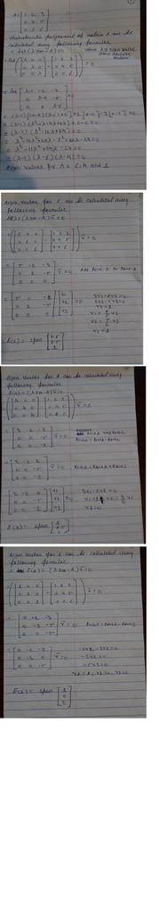

```r
knitr::include_graphics("https://github.com/mlforsachid/MSDSQ2Data605/blob/master/Week3/HW-3/HW-3.jpg?raw=true")
```

Verify using R

```r
stat = eigen(A)
print(stat$values)
```

```
## [1] 6 4 1
```

```r
print(stat$vectors)
```

```
##           [,1]      [,2] [,3]
## [1,] 0.5108407 0.5547002    1
## [2,] 0.7981886 0.8320503    0
## [3,] 0.3192754 0.0000000    0
```